# BIOL606 MIDTERM1 PRESENTATION GALLEGOSPEREZ, Lu

Samantha Gallegos Perez, Meilyn Lu

2026-02-05

## Load the metadata

Loaded the data into a variable called oc_data and used head() to check variables.

```r
oc_data = read_tsv("metadata-r-na_treat-diet.tsv")
head(oc_data)
```

```
## # A tibble: 6 × 27
##   `#SampleID` SampleID barcode     Subject Treatment Diet  Day     Age Ethnicity
##   <chr>       <chr>    <chr>         <dbl> <chr>     <chr> <chr> <dbl> <chr>
## 1 701C        701C     GCGATATATC…     701 Control   No P… Day 1    19 Asian
## 2 702C        702C     TACGAGCCCT…     702 Control   No P… Day 1    20 Asian
## 3 705C        705C     ATCCTTTGGT…     705 Control   No P… Day 1    23 Hispanic
## 4 706C        706C     TACAGCGCAT…     706 Control   No P… Day 1    21 White
## 5 732N        732N     AGATTGACCA…     732 User      No P… Day 1    20 White
## 6 734N        734N     ACTTCCAACT…     734 User      No P… Day 1    NA <NA>
## # ℹ 18 more variables: Height <dbl>, Weight <dbl>, BMI <dbl>,
## #   AgeOfMenarche <dbl>, AvgNumDaysBtwPeriods <chr>, OCE2Dosage <dbl>,
## #   AgeFirstOCUse <dbl>, TotalYearsOnOC <dbl>, BowelDiaryCollectionTime <chr>,
## #   BMperDay <dbl>, BMperWk <dbl>, AvgAmountPerWeek <dbl>, AvgCon <dbl>,
## #   AvgStrain <dbl>, AvgPain <dbl>, AvgFCons <dbl>, H2 <dbl>, CH4 <dbl>
```

# Data Collection and Data Wrangling

This metadata contains faecal samples collected from 65 women, comparing OC users with non-users at two menstrual cycle time points (Day 1 and Day 21). Breath tests measured hydrogen and CH4 production and other characteristics like Age, Ethnicity, Height, Weight, BMI, Age of Menarche, average number of days between periods, OCE2 dosage, age when first OC was used, total years on OC, bowel diary collection time, BM per day, BM per week, average amount per week, and average strain (Terrazas et al., Simpson et al.). These studies encourage our interest to understand how OC user history with our without a prune diet can influence H2 breath emissions.

## Our hypothesis: Does prune diet have an effect on H2 emissions and is it’s effect associated with years of Oral Contraceptive (OC) use?

The metadata contains rows of information focused on pre- and post test data that fall out of scope for this assignment. To fall within scope, we decided to focus on post test data that included OC users only from Day 21. To test our hypothesis, we would only use the variables, Diet, TotalYearsOnOC, and H2, and treat Diet as a categorical independent variable, TotalYearsOnOC as a continuous independent variable and H2 as continuous dependent variable.

Before proceeding with our analysis, we wrangled our data by changed our Diet variable, formerly as a ‘char’, to a ‘factor’. As well, we used the piping method to filter oc_data to focus on rows that include Treatment variable equal to ‘User’ and Day variable equal to ‘Day 21’.

```r
oc_data$Diet = as.factor(oc_data$Diet)#changed the data type from char to factor to continue with our analysis and assigned it to the same variable name

#Used the piping method to focus on dataframe oc_data, to filter rows of data from Day 21 under the Day column and OC users from the Treatment column
new_data = oc_data%>%
  filter(Treatment == "User" & Day == "Day 21")
```

# Initial Inspection

I completed a histogram on the H2 emission values to check to see if the response variable values formed a normal distribution.

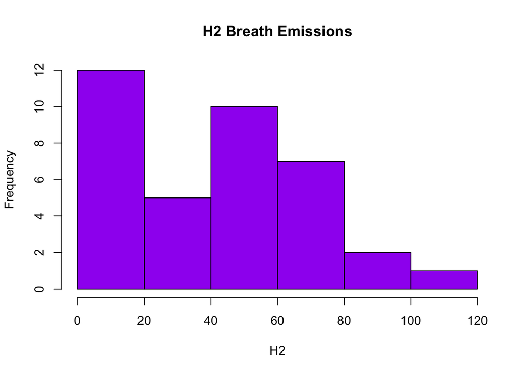

```r
#preview of H2 dependent variable
hist(new_data$H2,
     main= "H2 Breath Emissions",#changed the title of the histogram
     xlab= "H2", #renamed the x axis label
     border = "black",#changed the border of each bar to black
     col = "purple", #the overall color of the bars on the histogram
     breaks=5)
```

In order to proceed with analysis, we needed to use the proper test to understand if there was interaction between a categorical independent variable (Diet) and a continuous independent variable (TotalYearsOnOC) and its effect on a continuous dependent variable (H2). We created a linear model that tested for this interaction using the new_data that was properly filtered.

```r
#Linear Model to test the interaction between two independent variables
model = lm(H2~Diet*TotalYearsOnOC, data = new_data)#H2-DEPENDENT,TotalYearsOnOC-INDEPENDENT,Diet=INDEPENDENT
```

# Testing Assumptions

In this section, I am checking the assumptions of my model. The function, autoplot(), produces four diagnostic plots that can help check our data for heteroskedasticity, normality,etc. These plots are based on the residuals around the line.

Residual vs Fitted: There seems to be no hump shapes or valleys apparent,so I can say it looks ok. Normal Q-Q: This plot evaluates the assumption of normality and is a stronger tool to check for normality than a histogram. This plot looks ok. Scale-Location: This plot tests for equal variances, and there should be no pattern but here we can see a bit of fanning out. We chose to continue. Residuals vs Leverage: This plot detects influential points and potential outliers. Based on the plot, there seems to be no outliers, so we may continue.

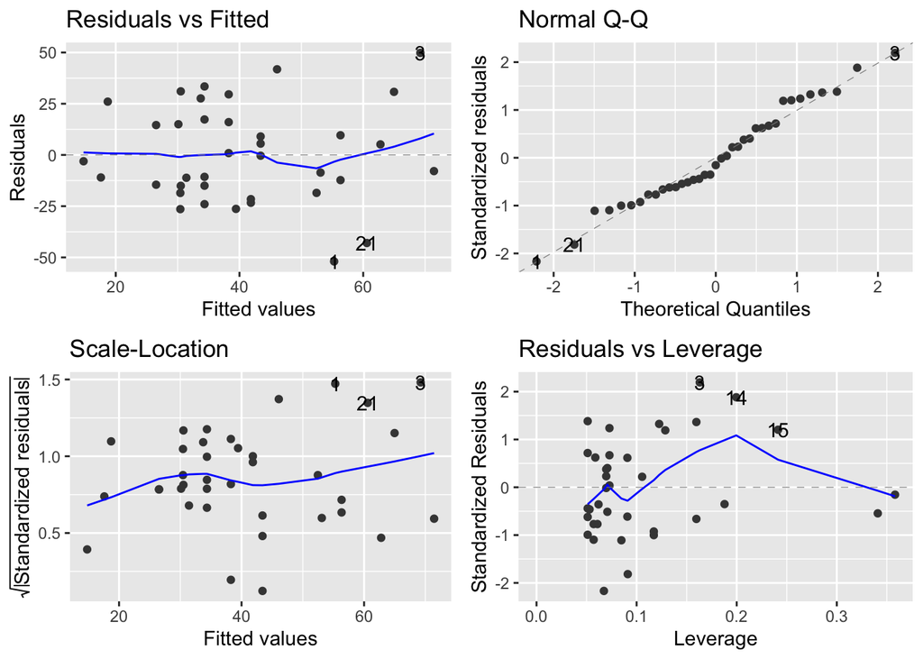

```r
#check assumptions using the autoplot() function from the ggfortify package
autoplot(model)
```

# ANCOVA Testing

This chunk of code will use the linear model, ‘model’, and use the anova() and summary() functions.

```r
#anova and summary
anova(model)
```

```
## Analysis of Variance Table
##
## Response: H2
##                     Df  Sum Sq Mean Sq F value  Pr(>F)
## Diet                 1  2495.4  2495.4  4.0507 0.05237 .
## TotalYearsOnOC       1  3396.4  3396.4  5.5132 0.02502 *
## Diet:TotalYearsOnOC  1  1362.4  1362.4  2.2115 0.14648
## Residuals           33 20329.5   616.0
## ---
## Signif. codes:  0 '***' 0.001 '**' 0.01 '*' 0.05 '.' 0.1 ' ' 1
```

```r
#After running the anova, I can see that the independent variable Diet, is considered to not be significant with a p-value of 0.05237, and TotalYearsOnOC with a p-value of 0.02502, significant. We can also see that the tested interaction is not significant with a p-value of 0.14648.

summary(model)
```

```
##
## Call:
## lm(formula = H2 ~ Diet * TotalYearsOnOC, data = new_data)
##
## Residuals:
##     Min      1Q  Median      3Q     Max
## -51.961 -15.063  -3.074  16.021  49.819
##
## Coefficients:
##                          Estimate Std. Error t value Pr(>|t|)
## (Intercept)                82.146     14.612   5.622 2.94e-06 ***
## DietPrune                 -32.158     20.027  -1.606   0.1179
## TotalYearsOnOC            -12.910      5.299  -2.436   0.0204 *
## DietPrune:TotalYearsOnOC    9.000      6.052   1.487   0.1465
## ---
## Signif. codes:  0 '***' 0.001 '**' 0.01 '*' 0.05 '.' 0.1 ' ' 1
##
## Residual standard error: 24.82 on 33 degrees of freedom
##   (2 observations deleted due to missingness)
## Multiple R-squared:  0.263,  Adjusted R-squared:  0.196
## F-statistic: 3.925 on 3 and 33 DF,  p-value: 0.01681
```

```r
#provides a table of estimates of the coefficients of the line that is the model. In this case, the linear equations would be:

#No prune linear: H2=-12.91(YearsOC)+82.15
#Prune linear:    H2=-3.91(YearsOC)+49.99
```

## Final Visualization

This final visualization will plot our y, H2 emission, as a function of x, our two independent variables, Diet, and TotalYearsOnOC. We also created a regression line to the plot and the grey-ish color surrounding the regression line depicts the confidence level.

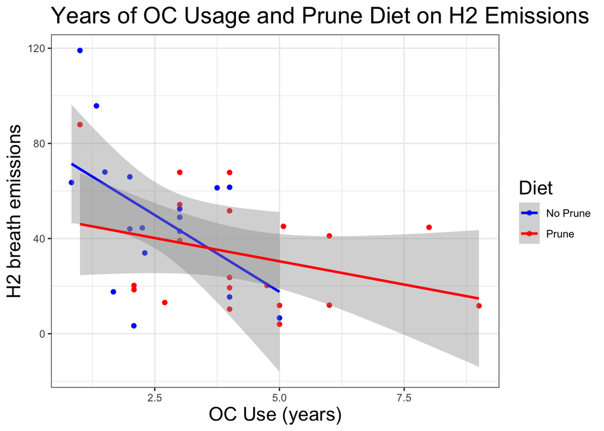

```r
#create final visualization using x=continuous independent variable, y=continuous dependent variable,
#and color as a continuous independent variable.
ggplot(new_data, aes(x=TotalYearsOnOC, y=H2, color = Diet)) +
  geom_point() + #creates the scatterplot to see how the data trends
  scale_color_manual(values=c('No Prune'="blue", 'Prune' ="red")) + theme_bw() +
  geom_smooth(method="lm") + #creates the regression line and confidence level around it
  theme(
    axis.title.x= element_text(size=16), #adjusts the x axis title size
    axis.title.y=element_text(size=16), #adjusts the y axis title size
    title=element_text(size=16)) + #adjusts the tile label size
  labs(title="Years of OC Usage and Prune Diet on H2 Emissions", #creates the figure title
       x= "OC Use (years)", #creates the x axis label name
       y= "H2 breath emissions") #creates y axis label name
```

# Conclusion